# Analyses: Disentangling social-relational classroom climate and its relation to students’ behavioral problems

Jürgen Wilbert

Version (2021-06-21)

# Software acknowledgment

The following packages were used for this report:

`R` at version R version 4.1.0 (2021-05-18) (R Core Team 2020).

# Research questions

Q1: Is there a general factor that could be derived from various aspects of students relations within the classroom (ie. social inclusion; social position; bullying involvement; acceptance by the teacher) ?

Q1a: On an individual level: Is it possible to conflate various aspects of students relations within the classroom into one distinct general factor (social-relational situation)?

Q1b: On a classroom level: Is it possible to conflate the classroom means of various aspects of students relations into on distinct general factor (social-relational classroom climate)?

Q2: What is the connection between students behavioral problems and various aspects of their social relations?

Q2a: On an individual level: To what extend can students behavioral problems in a class be explained by means of various aspects of their social relations?

Q2b: In extension of hypothesis Q2a: To what extend do classroom means of various aspects of students social relations contribute to individual behavioral classroom problems?

Q2c: On a classroom level: To what extend can the average amount of behavioral problems in a classroom be explained by classroom means of various aspects of students social relations?

# Analyzing strategy

[This paragraph will later be included into the manuscript and deleted here]

*Question 1a: Factor structure of social-relation variables*

*Question 1b: Factor structure of Social-relational classclimate variables*

*Question 2a and b: Social-relations and behavior problems*

*Question 2c: Social-relational classclimate and average behavior problems*

(Foster-Johnson, L., & Kromrey, J. D. (2018). Predicting group-level outcome variables: An empirical comparison of analysis strategies. Behavior Research Methods, 50(6), 2461–2479. https://doi.org/10.3758/s13428-018-1025-8)

# Material

Item Analyzes with the data of the present study.

| Scale | n | n items | Alpha(CI95%) | Std.Alpha(CI95%) | Homogeneity | Discrimination | M | SD | \|Loading\| |
| --- | --- | --- | --- | --- | --- | --- | --- | --- | --- |
| Social withdrawal | 1.71e+03 | 8 | .9 (.89-.9) | .9 (.9-.91) | .54 | .59 - .78 | 0.18 - 0.4 | 0.47 - 0.73 | .6 - .85 |
| Anxious/depressed | 1.71e+03 | 11 | .88 (.88-.89) | .88 (.87-.89) | .41 | .45 - .75 | 0.16 - 0.39 | 0.5 - 0.69 | .47 - .8 |
| Academically disorganized | 1.71e+03 | 8 | .92 (.91-.92) | .92 (.91-.93) | .59 | .58 - .8 | 0.35 - 0.93 | 0.73 - 1.02 | .6 - .84 |
| Oppositional behavior | 1.71e+03 | 8 | .93 (.93-.93) | .93 (.93-.94) | .63 | .7 - .82 | 0.27 - 0.69 | 0.67 - 0.9 | .72 - .85 |
| FEESS 1/2 teacher acceptance | 788 | 8 | .69 (.67-.71) | .7 (.68-.72) | .23 | .32 - .45 | 0.73 - 0.94 | 0.24 - 0.44 | .39 - .57 |
| FEESS 3/4 teacher acceptance | 853 | 8 | .82 (.81-.83) | .83 (.82-.84) | .37 | .44 - .61 | 2.02 - 2.63 | 0.7 - 1.05 | .48 - .7 |
| FEESS 1/2 social inclusion | 787 | 6 | .59 (.56-.61) | .6 (.57-.62) | .2 | .26 - .38 | 0.62 - 0.85 | 0.35 - 0.49 | .33 - .55 |
| FEESS 3/4 social inclusion | 853 | 6 | .75 (.73-.76) | .75 (.73-.77) | .33 | .41 - .56 | 2.02 - 2.49 | 0.72 - 0.99 | .48 - .68 |
| Bullying perpetrator | 1.72e+03 | 4 | .84 (.82-.85) | .84 (.83-.85) | .56 | .57 - .83 | 0.12 - 0.38 | 0.45 - 0.71 | .61 - .96 |
| Bullying victim | 1.72e+03 | 4 | .78 (.77-.8) | .8 (.78-.81) | .5 | .46 - .76 | 0.06 - 0.29 | 0.26 - 0.58 | .52 - .9 |

# Descriptives of all variables

[output not shown]

| name | valid | missing | mean | sd | min | max | range | median | mad |
| --- | --- | --- | --- | --- | --- | --- | --- | --- | --- |
| Teacher acceptance | 1.64e+03 | 405 | 0.76 | 0.22 | 0 | 1 | 1 | 0.83 | 0.25 |
| Social integration | 1.64e+03 | 405 | 0.75 | 0.21 | 0 | 1 | 1 | 0.83 | 0.25 |
| Social relatedness | 1.72e+03 | 329 | 0.27 | 0.09 | 0 | 0.72 | 0.72 | 0.27 | 0.1 |
| Social positivity | 1.72e+03 | 329 | 0.55 | 0.14 | 0.02 | 0.97 | 0.95 | 0.56 | 0.13 |
| Bullying victim | 1.72e+03 | 325 | 0.18 | 0.35 | 0 | 3 | 3 | 0 | 0 |
| Bullying perpetrator | 1.72e+03 | 325 | 0.27 | 0.49 | 0 | 3 | 3 | 0 | 0 |
| Scale Socially withdrawn behaviour | 1.71e+03 | 337 | 0.28 | 0.48 | 0 | 3 | 3 | 0 | 0 |
| Scale Anxious/Depressed behaviour | 1.71e+03 | 337 | 0.28 | 0.43 | 0 | 3 | 3 | 0.09 | 0.13 |
| Scale Academic productive/disorganized behaviour | 1.71e+03 | 338 | 0.64 | 0.72 | 0 | 3 | 3 | 0.38 | 0.56 |
| Scale Oppositional/Disruptive behaviour | 1.71e+03 | 338 | 0.43 | 0.63 | 0 | 3 | 3 | 0.12 | 0.19 |
| Age | 1.96e+03 | 86 | 8.57 | 1.29 | 6.08 | 11.9 | 5.83 | 8.58 | 1.61 |
| Sex male | 2.03e+03 | 11 | 0.51 | 0.5 | 0 | 1 | 1 | 1 | 0 |
| Migration background | 1.9e+03 | 149 | 0.34 | 0.47 | 0 | 1 | 1 | 0 | 0 |

| grade | n |
| --- | --- |
| 1 | 521 |
| 2 | 497 |
| 3 | 533 |
| 4 | 494 |

| sex | n |
| --- | --- |
| weiblich | 987 |
| männlich | 1047 |
|  | 11 |

| migration_background | n |
| --- | --- |
| nein | 1258 |
| ja | 638 |
|  | 149 |

```
## Correlation matrix.
## Probability signs above the diagonal are adjusted for multiple tests.
## Tp<.10; *p<.05; **p<.01; ***p<.001.
```

| M | SD | 1 | 2 | 3 | 4 | 5 | 6 | 7 | 8 | 9 | 10 | 11 | 12 | 13 |
| --- | --- | --- | --- | --- | --- | --- | --- | --- | --- | --- | --- | --- | --- | --- |
| 0.76 | 0.22 | - |  |  |  |  |  |  |  |  |  |  |  |  |
| 0.75 | 0.21 | .74*** | - |  |  |  |  |  |  |  |  |  |  |  |
| 0.27 | 0.09 | -.05T | .00 | - |  |  |  |  |  |  |  |  |  |  |
| 0.55 | 0.14 | .23*** | .34*** | -.12*** | - |  |  |  |  |  |  |  |  |  |
| 0.18 | 0.35 | -.14*** | -.20*** | .13*** | -.36*** | - |  |  |  |  |  |  |  |  |
| 0.27 | 0.49 | -.18*** | -.16*** | .16*** | -.31*** | .62*** | - |  |  |  |  |  |  |  |
| 0.28 | 0.48 | -.13*** | -.16*** | -.08** | -.20*** | .26*** | .17*** | - |  |  |  |  |  |  |
| 0.28 | 0.43 | -.12*** | -.16*** | -.03 | -.16*** | .33*** | .27*** | .59*** | - |  |  |  |  |  |
| 0.64 | 0.72 | -.24*** | -.24*** | .09*** | -.38*** | .33*** | .39*** | .41*** | .36*** | - |  |  |  |  |
| 0.43 | 0.63 | -.21*** | -.18*** | .16*** | -.36*** | .52*** | .77*** | .13*** | .28*** | .45*** | - |  |  |  |
| 8.57 | 1.29 | -.03 | .00 | .30*** | -.01 | .06* | .03 | .00 | .05T | .08** | .01 | - |  |  |
| 0.51 | 0.50 | -.12*** | -.03 | .15*** | -.20*** | .11*** | .18*** | .06* | .01 | .18*** | .23*** | .01 | - |  |
| 0.34 | 0.47 | -.06* | -.08** | -.02 | -.10*** | .08*** | .07** | .06* | .01 | .09*** | .06* | .04 | .01 | - |

| name | valid | missing | mean | sd | min | max | range | median | mad |
| --- | --- | --- | --- | --- | --- | --- | --- | --- | --- |
| Average tacher acceptance | 86 | 1 | 0.76 | 0.09 | 0.52 | 0.94 | 0.43 | 0.76 | 0.08 |
| Average social inclusion | 86 | 1 | 0.75 | 0.08 | 0.58 | 0.94 | 0.36 | 0.76 | 0.06 |
| Average social relatedness | 84 | 3 | 0.27 | 0.07 | 0.11 | 0.4 | 0.28 | 0.27 | 0.08 |
| Average social positivity | 84 | 3 | 0.55 | 0.05 | 0.46 | 0.71 | 0.25 | 0.55 | 0.04 |
| Average bullying victim | 87 | 0 | 0.18 | 0.16 | 0 | 0.7 | 0.7 | 0.15 | 0.14 |
| Average bullying perpetrator | 87 | 0 | 0.27 | 0.27 | 0 | 2 | 2 | 0.22 | 0.17 |
| Average social withdrawal | 87 | 0 | 0.29 | 0.23 | 0 | 1.81 | 1.81 | 0.22 | 0.15 |
| Average anxiety/depression | 87 | 0 | 0.29 | 0.24 | 0 | 1.8 | 1.8 | 0.24 | 0.19 |
| Average academically disorganized | 87 | 0 | 0.64 | 0.27 | 0.17 | 2.08 | 1.91 | 0.59 | 0.21 |
| Average oppositional behavior | 87 | 0 | 0.43 | 0.26 | 0.09 | 1.65 | 1.56 | 0.37 | 0.18 |
| Average age | 86 | 1 | 8.6 | 1.08 | 6.82 | 10.5 | 3.69 | 8.53 | 1.1 |
| Proportion male | 86 | 1 | 0.52 | 0.09 | 0.31 | 0.82 | 0.51 | 0.52 | 0.08 |
| Proportion migration background | 85 | 2 | 0.36 | 0.25 | 0 | 1 | 1 | 0.35 | 0.32 |

```
## Correlation matrix.
## Probability signs above the diagonal are adjusted for multiple tests.
## Tp<.10; *p<.05; **p<.01; ***p<.001.
```

| M | SD | 1 | 2 | 3 | 4 | 5 | 6 | 7 | 8 | 9 | 10 | 11 | 12 | 13 |
| --- | --- | --- | --- | --- | --- | --- | --- | --- | --- | --- | --- | --- | --- | --- |
| 0.76 | 0.09 | - |  |  |  |  |  |  |  |  |  |  |  |  |
| 0.75 | 0.08 | .69*** | - |  |  |  |  |  |  |  |  |  |  |  |
| 0.27 | 0.07 | .03 | .06 | - |  |  |  |  |  |  |  |  |  |  |
| 0.55 | 0.05 | .32** | .50*** | .06 | - |  |  |  |  |  |  |  |  |  |
| 0.18 | 0.16 | -.14 | -.17 | .06 | -.09 | - |  |  |  |  |  |  |  |  |
| 0.27 | 0.27 | -.21* | -.18 | .01 | -.12 | .78*** | - |  |  |  |  |  |  |  |
| 0.29 | 0.23 | -.05 | -.01 | .09 | .18 | .53*** | .70*** | - |  |  |  |  |  |  |
| 0.29 | 0.24 | -.11 | -.18T | .02 | .02 | .62*** | .77*** | .82*** | - |  |  |  |  |  |
| 0.64 | 0.27 | -.15 | -.10 | .13 | .09 | .52*** | .69*** | .69*** | .64*** | - |  |  |  |  |
| 0.43 | 0.26 | -.24* | -.24* | -.10 | -.10 | .69*** | .85*** | .63*** | .75*** | .68*** | - |  |  |  |
| 8.60 | 1.08 | -.03 | .06 | .53*** | .08 | .15 | .04 | .05 | .13 | .20T | .02 | - |  |  |
| 0.52 | 0.09 | -.16 | -.22* | .09 | -.14 | .24* | .19T | .13 | .22* | .21* | .23* | .04 | - |  |
| 0.36 | 0.25 | -.11 | -.16 | .01 | .09 | .02 | .09 | .13 | .24* | .17 | .28** | .01 | .03 | - |

# Experimental Multilevel Confirmatory Factor analyzes

```
## lavaan 0.6-8 ended normally after 98 iterations
##
##   Estimator                                         ML
##   Optimization method                           NLMINB
##   Number of model parameters                        30
##
##                                                   Used       Total
##   Number of observations                          1411        2045
##   Number of clusters [id_class_teacher]             84
##
## Model Test User Model:
##
##   Test statistic                               847.045
##   Degrees of freedom                                18
##   P-value (Chi-square)                           0.000
##
## Model Test Baseline Model:
##
##   Test statistic                              2323.924
##   Degrees of freedom                                30
##   P-value                                        0.000
##
## User Model versus Baseline Model:
##
##   Comparative Fit Index (CFI)                    0.639
##   Tucker-Lewis Index (TLI)                       0.398
##
## Loglikelihood and Information Criteria:
##
##   Loglikelihood user model (H0)               2242.206
##   Loglikelihood unrestricted model (H1)       2665.729
##
##   Akaike (AIC)                               -4424.413
##   Bayesian (BIC)                             -4266.851
##   Sample-size adjusted Bayesian (BIC)        -4362.150
##
## Root Mean Square Error of Approximation:
##
##   RMSEA                                          0.181
##   90 Percent confidence interval - lower         0.170
```

[output cut: 82 more lines]

```
##    .feess_si          0.002    0.001    3.046    0.002
##    .soc_relatednss    0.004    0.001    6.085    0.000
##    .soc_positivity    0.001    0.000    2.005    0.045
##    .sar_victim        0.002    0.004    0.428    0.669
##    .sar_perpetratr   -0.007    0.007   -0.933    0.351
##     social_relatns    1.000
##
## R-Square:
##                    Estimate
##     feess_ga          0.083
##     feess_si          0.081
##     soc_relatednss    0.002
##     soc_positivity    0.093
##     sar_victim        0.909
##     sar_perpetratr       NA
```

# Q1a

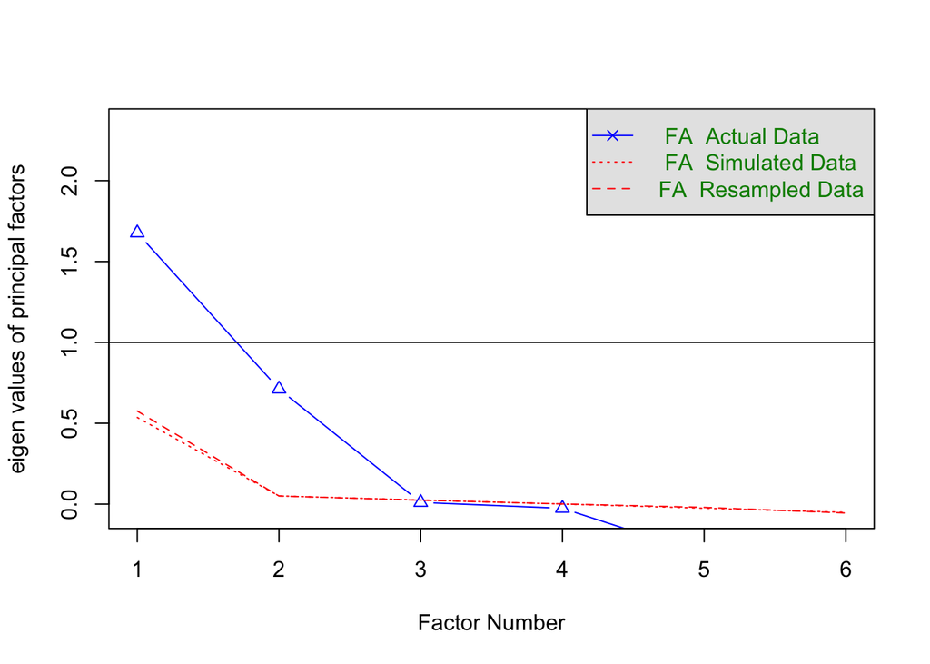

Parallel analysis scree plot.

```
## Parallel analysis suggests that the number of factors =  2  and the number of components =  NA
```

Exploratory factor analyzes of social relation variables.

| MR1 | MR2 |
| --- | --- |
| 1 |  |
| 0.72 |  |
|  | 0.82 |
|  | 0.76 |
| 0.23 | -0.38 |
|  | 0.2 |
| 1.61 | 1.45 |
| 0.27 | 0.24 |
| 0.27 | 0.51 |
| 0.53 | 0.47 |
| 0.53 | 1 |

# Q1b

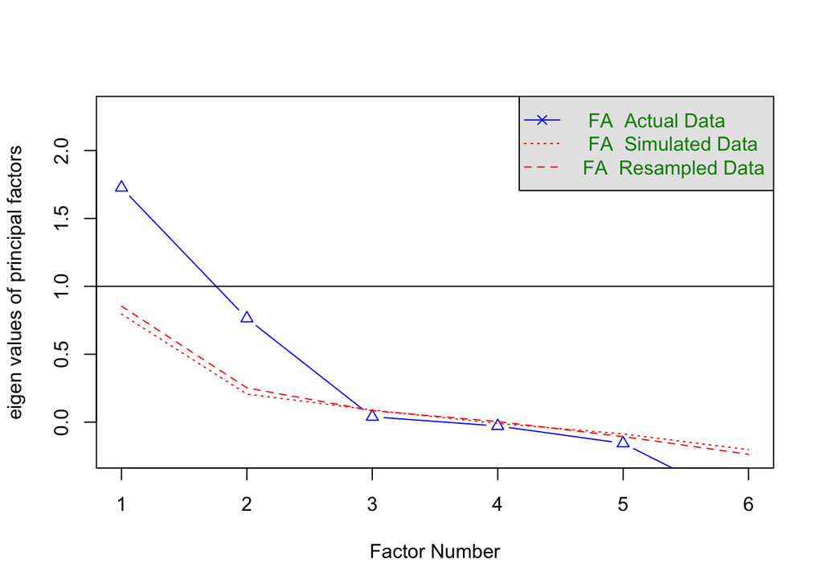

Parallel analysis scree plot.

```
## Parallel analysis suggests that the number of factors =  2  and the number of components =  NA
```

Exploratory factor analyzes of mean social relation variables.

| MR1 | MR2 |
| --- | --- |
| 1.01 |  |
| 0.67 |  |
| 0.49 |  |
|  | 0.99 |
|  | 0.78 |
| 1.7 | 1.61 |
| 0.28 | 0.27 |
| 0.28 | 0.55 |
| 0.51 | 0.49 |
| 0.51 | 1 |

# Q2a, Q2b, and Q2c

> Note for my co-authors: I changed the analyzes for Q2c from an aggregated OLS regression approach to a multilevel means-as-outcome model. While the unstandardized estimators are very similar in both models, the latter (means-as-outcome) model has much lower standardized betas. Probably this is due to a significant proportion of within class variance that has not been accounted for in the simple aggregated OLS regression (due to the aggregation). The change allows for representing all three models in one table, which I find much more convenient.

For calculating the influence of the average social relations within a class on the average behavior problems in a class, we fitted a mean-as-outcome model to the data. Mean-as-outcome model are multilevel models with level 2 predictors (here: the class level) but no level 1 predictors (here: the indivdual level). As a result, the predictors describe the changes in the grand mean of the criteria variable (here: behavior problems) that is due to compositional (here: means) aspects of students social relations within a class.

Social withdrawal regressed on individual social-relations and social-relational classclimate

|  | Model 1 (L1) |  |  | Model 2 (L1+L2) |  |  | Model 3 (mean-as-outcome) |  |  |
| --- | --- | --- | --- | --- | --- | --- | --- | --- | --- |
| Predictors | Beta | SE | p | Beta | SE | p | Beta | SE | p |
| (Intercept) | 0.01 | 0.04 | **<0.001** | -0.00 | 0.04 | 0.637 | -0.00 | 0.04 | 0.473 |
| Social integration | -0.04 | 0.04 | 0.363 | -0.04 | 0.04 | 0.367 |  |  |  |
| Teacher acceptance | -0.06 | 0.04 | 0.136 | -0.07 | 0.04 | 0.106 |  |  |  |
| Social relatedness | -0.17 | 0.03 | **<0.001** | -0.23 | 0.04 | **<0.001** |  |  |  |
| Social positivity | -0.13 | 0.03 | **<0.001** | -0.16 | 0.03 | **<0.001** |  |  |  |
| Bullying victim | 0.24 | 0.03 | **<0.001** | 0.23 | 0.04 | **<0.001** |  |  |  |
| Bullying perpetrator | -0.09 | 0.03 | **0.008** | -0.09 | 0.03 | **0.007** |  |  |  |
| migration_background1 | 0.02 | 0.03 | 0.419 | 0.00 | 0.03 | 0.904 |  |  |  |
| Age | 0.02 | 0.04 | 0.509 | -0.00 | 0.05 | 0.940 |  |  |  |
| sex1 | 0.03 | 0.03 | 0.306 | 0.03 | 0.03 | 0.231 |  |  |  |
| Average social inclusion |  |  |  | 0.01 | 0.06 | 0.804 | 0.00 | 0.06 | 0.947 |
| Average tacher acceptance |  |  |  | 0.04 | 0.06 | 0.464 | -0.02 | 0.05 | 0.727 |
| Average social relatedness |  |  |  | 0.17 | 0.05 | **0.002** | 0.03 | 0.04 | 0.475 |
| Average social positivity |  |  |  | 0.10 | 0.04 | **0.025** | 0.08 | 0.04 | **0.045** |
| Average bullying victim |  |  |  | 0.00 | 0.07 | 0.998 | 0.11 | 0.06 | 0.083 |
| Average bullying perpetrator |  |  |  | 0.11 | 0.07 | 0.103 | 0.05 | 0.06 | 0.473 |
| Average age |  |  |  | -0.03 | 0.06 | 0.652 | -0.05 | 0.04 | 0.290 |
| Proportion migration background |  |  |  | 0.05 | 0.04 | 0.275 | 0.03 | 0.04 | 0.422 |
| Proportion male |  |  |  | 0.01 | 0.04 | 0.725 | 0.03 | 0.04 | 0.507 |
| Random Effects |  |  |  |  |  |  |  |  |  |
| σ<sup>2</sup> | 0.16 |  |  | 0.16 |  |  | 0.20 |  |  |
| τ<sub>00</sub> | 0.02 <sub>id_class_teacher</sub> |  |  | 0.01 <sub>id_class_teacher</sub> |  |  | 0.01 <sub>id_class_teacher</sub> |  |  |
| ICC | 0.09 |  |  | 0.07 |  |  | 0.06 |  |  |
| N | 83 <sub>id_class_teacher</sub> |  |  | 83 <sub>id_class_teacher</sub> |  |  | 83 <sub>id_class_teacher</sub> |  |  |
| Observations | 1345 |  |  | 1345 |  |  | 1630 |  |  |
| Marginal R<sup>2</sup> / Conditional R<sup>2</sup> | 0.112 / 0.194 |  |  | 0.134 / 0.195 |  |  | 0.031 / 0.088 |  |  |

Anxiety/depression regressed on individual social-relations and social-relational classclimate

|  | Model 1 (L1) |  |  | Model 2 (L1+L2) |  |  | Model 3 (mean-as-outcome) |  |  |
| --- | --- | --- | --- | --- | --- | --- | --- | --- | --- |
| Predictors | Beta | SE | p | Beta | SE | p | Beta | SE | p |
| (Intercept) | -0.02 | 0.05 | **0.001** | -0.03 | 0.04 | 0.586 | 0.00 | 0.04 | 0.500 |
| Social integration | -0.03 | 0.04 | 0.396 | -0.01 | 0.04 | 0.719 |  |  |  |
| Teacher acceptance | -0.06 | 0.04 | 0.120 | -0.07 | 0.04 | 0.062 |  |  |  |
| Social relatedness | -0.07 | 0.03 | **0.032** | -0.07 | 0.04 | 0.059 |  |  |  |
| Social positivity | -0.06 | 0.03 | **0.041** | -0.08 | 0.03 | **0.008** |  |  |  |
| Bullying victim | 0.27 | 0.03 | **<0.001** | 0.26 | 0.03 | **<0.001** |  |  |  |
| Bullying perpetrator | -0.01 | 0.03 | 0.675 | -0.03 | 0.03 | 0.325 |  |  |  |
| migration_background1 | -0.06 | 0.03 | **0.030** | -0.09 | 0.03 | **0.004** |  |  |  |
| Age | 0.04 | 0.04 | 0.254 | 0.05 | 0.05 | 0.292 |  |  |  |
| sex1 | -0.03 | 0.03 | 0.226 | -0.04 | 0.03 | 0.164 |  |  |  |
| Average social inclusion |  |  |  | -0.11 | 0.06 | 0.075 | -0.08 | 0.06 | 0.169 |
| Average tacher acceptance |  |  |  | 0.12 | 0.06 | 0.052 | 0.06 | 0.05 | 0.296 |
| Average social relatedness |  |  |  | 0.01 | 0.05 | 0.843 | -0.03 | 0.04 | 0.461 |
| Average social positivity |  |  |  | 0.07 | 0.05 | 0.138 | 0.05 | 0.04 | 0.281 |
| Average bullying victim |  |  |  | 0.00 | 0.07 | 0.952 | 0.12 | 0.07 | 0.074 |
| Average bullying perpetrator |  |  |  | 0.15 | 0.07 | **0.035** | 0.14 | 0.07 | **0.037** |
| Average age |  |  |  | -0.02 | 0.06 | 0.759 | 0.04 | 0.05 | 0.445 |
| Proportion migration background |  |  |  | 0.10 | 0.04 | **0.032** | 0.07 | 0.04 | 0.095 |
| Proportion male |  |  |  | 0.06 | 0.04 | 0.144 | 0.04 | 0.04 | 0.262 |
| Random Effects |  |  |  |  |  |  |  |  |  |
| σ<sup>2</sup> | 0.14 |  |  | 0.14 |  |  | 0.15 |  |  |
| τ<sub>00</sub> | 0.02 <sub>id_class_teacher</sub> |  |  | 0.01 <sub>id_class_teacher</sub> |  |  | 0.01 <sub>id_class_teacher</sub> |  |  |
| ICC | 0.13 |  |  | 0.09 |  |  | 0.08 |  |  |
| N | 83 <sub>id_class_teacher</sub> |  |  | 83 <sub>id_class_teacher</sub> |  |  | 83 <sub>id_class_teacher</sub> |  |  |
| Observations | 1345 |  |  | 1345 |  |  | 1630 |  |  |
| Marginal R<sup>2</sup> / Conditional R<sup>2</sup> | 0.106 / 0.221 |  |  | 0.166 / 0.243 |  |  | 0.080 / 0.150 |  |  |

Academic disorganized behavior regressed on individual social-relations and social-relational classclimate

|  | Model 1 (L1) |  |  | Model 2 (L1+L2) |  |  | Model 3 (mean-as-outcome) |  |  |
| --- | --- | --- | --- | --- | --- | --- | --- | --- | --- |
| Predictors | Beta | SE | p | Beta | SE | p | Beta | SE | p |
| (Intercept) | 0.00 | 0.03 | **<0.001** | -0.00 | 0.03 | 0.291 | -0.01 | 0.03 | 0.468 |
| Social integration | -0.02 | 0.04 | 0.512 | -0.02 | 0.04 | 0.554 |  |  |  |
| Teacher acceptance | -0.10 | 0.04 | **0.006** | -0.11 | 0.04 | **0.003** |  |  |  |
| Social relatedness | -0.02 | 0.03 | 0.470 | -0.02 | 0.04 | 0.588 |  |  |  |
| Social positivity | -0.25 | 0.03 | **<0.001** | -0.27 | 0.03 | **<0.001** |  |  |  |
| Bullying victim | 0.09 | 0.03 | **0.004** | 0.09 | 0.03 | **0.008** |  |  |  |
| Bullying perpetrator | 0.21 | 0.03 | **<0.001** | 0.20 | 0.03 | **<0.001** |  |  |  |
| migration_background1 | 0.02 | 0.03 | 0.464 | 0.01 | 0.03 | 0.803 |  |  |  |
| Age | 0.08 | 0.03 | **0.014** | 0.06 | 0.05 | 0.166 |  |  |  |
| sex1 | 0.05 | 0.02 | **0.049** | 0.04 | 0.03 | 0.076 |  |  |  |
| Average social inclusion |  |  |  | -0.01 | 0.05 | 0.775 | -0.02 | 0.05 | 0.720 |
| Average tacher acceptance |  |  |  | 0.06 | 0.05 | 0.192 | -0.02 | 0.04 | 0.700 |
| Average social relatedness |  |  |  | -0.02 | 0.04 | 0.686 | -0.00 | 0.04 | 0.925 |
| Average social positivity |  |  |  | 0.14 | 0.04 | **<0.001** | 0.06 | 0.03 | 0.095 |
| Average bullying victim |  |  |  | -0.06 | 0.06 | 0.301 | -0.01 | 0.05 | 0.866 |
| Average bullying perpetrator |  |  |  | 0.08 | 0.06 | 0.138 | 0.14 | 0.05 | **0.012** |
| Average age |  |  |  | 0.02 | 0.05 | 0.704 | 0.06 | 0.04 | 0.142 |
| Proportion migration background |  |  |  | 0.01 | 0.03 | 0.687 | 0.03 | 0.03 | 0.367 |
| Proportion male |  |  |  | 0.02 | 0.03 | 0.556 | 0.04 | 0.03 | 0.230 |
| Random Effects |  |  |  |  |  |  |  |  |  |
| σ<sup>2</sup> | 0.34 |  |  | 0.34 |  |  | 0.47 |  |  |
| τ<sub>00</sub> | 0.02 <sub>id_class_teacher</sub> |  |  | 0.01 <sub>id_class_teacher</sub> |  |  | 0.01 <sub>id_class_teacher</sub> |  |  |
| ICC | 0.06 |  |  | 0.04 |  |  | 0.03 |  |  |
| N | 83 <sub>id_class_teacher</sub> |  |  | 83 <sub>id_class_teacher</sub> |  |  | 83 <sub>id_class_teacher</sub> |  |  |
| Observations | 1344 |  |  | 1344 |  |  | 1628 |  |  |
| Marginal R<sup>2</sup> / Conditional R<sup>2</sup> | 0.246 / 0.290 |  |  | 0.258 / 0.286 |  |  | 0.029 / 0.055 |  |  |

Oppositional behavior regressed on individual social-relations and social-relational classclimate

|  | Model 1 (L1) |  |  | Model 2 (L1+L2) |  |  | Model 3 (mean-as-outcome) |  |  |
| --- | --- | --- | --- | --- | --- | --- | --- | --- | --- |
| Predictors | Beta | SE | p | Beta | SE | p | Beta | SE | p |
| (Intercept) | -0.00 | 0.03 | **<0.001** | -0.01 | 0.02 | 0.297 | 0.00 | 0.02 | 0.505 |
| Social integration | 0.02 | 0.03 | 0.489 | 0.03 | 0.03 | 0.340 |  |  |  |
| Teacher acceptance | -0.06 | 0.03 | **0.028** | -0.06 | 0.03 | **0.021** |  |  |  |
| Social relatedness | 0.06 | 0.02 | **0.004** | 0.10 | 0.03 | **<0.001** |  |  |  |
| Social positivity | -0.10 | 0.02 | **<0.001** | -0.10 | 0.02 | **<0.001** |  |  |  |
| Bullying victim | 0.06 | 0.02 | **0.013** | 0.06 | 0.02 | **0.007** |  |  |  |
| Bullying perpetrator | 0.67 | 0.02 | **<0.001** | 0.66 | 0.02 | **<0.001** |  |  |  |
| migration_background1 | -0.01 | 0.02 | 0.547 | -0.03 | 0.02 | 0.097 |  |  |  |
| Age | -0.01 | 0.02 | 0.681 | 0.02 | 0.03 | 0.555 |  |  |  |
| sex1 | 0.05 | 0.02 | **0.003** | 0.05 | 0.02 | **0.006** |  |  |  |
| Average social inclusion |  |  |  | -0.04 | 0.04 | 0.341 | -0.03 | 0.04 | 0.402 |
| Average tacher acceptance |  |  |  | 0.03 | 0.04 | 0.423 | 0.01 | 0.03 | 0.798 |
| Average social relatedness |  |  |  | -0.11 | 0.03 | **0.002** | -0.05 | 0.03 | 0.110 |
| Average social positivity |  |  |  | 0.03 | 0.03 | 0.321 | 0.00 | 0.03 | 0.927 |
| Average bullying victim |  |  |  | -0.05 | 0.04 | 0.265 | -0.03 | 0.04 | 0.490 |
| Average bullying perpetrator |  |  |  | 0.04 | 0.04 | 0.355 | 0.30 | 0.04 | **<0.001** |
| Average age |  |  |  | 0.00 | 0.04 | 0.978 | 0.02 | 0.03 | 0.467 |
| Proportion migration background |  |  |  | 0.08 | 0.03 | **0.004** | 0.06 | 0.02 | **0.015** |
| Proportion male |  |  |  | 0.00 | 0.03 | 0.986 | 0.03 | 0.02 | 0.305 |
| Random Effects |  |  |  |  |  |  |  |  |  |
| σ<sup>2</sup> | 0.14 |  |  | 0.14 |  |  | 0.35 |  |  |
| τ<sub>00</sub> | 0.01 <sub>id_class_teacher</sub> |  |  | 0.01 <sub>id_class_teacher</sub> |  |  | 0.00 <sub>id_class_teacher</sub> |  |  |
| ICC | 0.08 |  |  | 0.06 |  |  | 0.00 |  |  |
| N | 83 <sub>id_class_teacher</sub> |  |  | 83 <sub>id_class_teacher</sub> |  |  | 83 <sub>id_class_teacher</sub> |  |  |
| Observations | 1344 |  |  | 1344 |  |  | 1628 |  |  |
| Marginal R<sup>2</sup> / Conditional R<sup>2</sup> | 0.604 / 0.635 |  |  | 0.614 / 0.638 |  |  | 0.093 / 0.093 |  |  |

# Reference

Bates, Douglas, Martin Maechler, Ben Bolker, and Steven Walker. 2020. *Lme4: Linear Mixed-Effects Models Using ’Eigen’ and S4*. https://CRAN.R-project.org/package=lme4.

Honaker, James, Gary King, and Matthew Blackwell. 2019. *Amelia: A Program for Missing Data*. https://CRAN.R-project.org/package=Amelia.

Lüdecke, Daniel. 2020. *sjPlot: Data Visualization for Statistics in Social Science*. https://CRAN.R-project.org/package=sjPlot.

Pinheiro, José, Douglas Bates, and R-core. 2020. *Nlme: Linear and Nonlinear Mixed Effects Models*. https://CRAN.R-project.org/package=nlme.

R Core Team. 2020. *R: A Language and Environment for Statistical Computing*. Vienna, Austria: R Foundation for Statistical Computing. https://www.R-project.org/.

Revelle, William. 2020. *Psych: Procedures for Psychological, Psychometric, and Personality Research*. https://CRAN.R-project.org/package=psych.

Rosseel, Yves, Terrence D. Jorgensen, and Nicholas Rockwood. 2020. *Lavaan: Latent Variable Analysis*. https://CRAN.R-project.org/package=lavaan.

Wickham, Hadley. 2019. *Tidyverse: Easily Install and Load the ’Tidyverse’*. https://CRAN.R-project.org/package=tidyverse.

Wickham, Hadley, and Jennifer Bryan. 2019. *Readxl: Read Excel Files*. https://CRAN.R-project.org/package=readxl.

Wilbert, Juergen. 2020a. *Scaledic: Functions and Data Frame Extension for Scale Based Operations*.

———. 2020b. *Wmisc: Wilbert Miscellaneous Functions*.

Xie, Yihui. 2020a. *Bookdown: Authoring Books and Technical Documents with r Markdown*. https://CRAN.R-project.org/package=bookdown.

———. 2020b. *Knitr: A General-Purpose Package for Dynamic Report Generation in r*. https://CRAN.R-project.org/package=knitr.

Zhu, Hao. 2020. *kableExtra: Construct Complex Table with ’Kable’ and Pipe Syntax*. https://CRAN.R-project.org/package=kableExtra.